# The Best that No One Ever Was

Chan Hur

May 8, 2018

## Background

As most people who have played the games know, at its core, pokemon is like a Rock-Paper-Scissors game with types associated with each pokemon i.e. fire, water, etc., only that there are now 18 types which is 3 more since its inception. The increase may seem small, but in actuality, we are looking at interactions from a 15x15 to an 18x18 which is an additional 100 possible interactions. Not to mention, the pokemon cast has risen from the original 151 to an astounding 800. The data used was compiled by people on Kaggle and came in three files: combat which had simulated battles, tests which was without results, and pokemon for descriptions of pokemon including types and base stats.

## Methods

The data collected looks like it was scraped from data bases revolving around the game so they are objective measures free of bias.  
Because the main focus of pokemon are types, looking at them and how they associate with a pokemon’s stats will be important. I began with looking at how the types were distributed with visualizations. It looks like a majority of the pokemon have a single type which isn’t too surprising. The combinations of types does not look uniformly distributed. Rarer types like fairy are not too varied but types like bug and water have many secondary types associated. This could play a factor in potential match ups since a more prevalent type may end up being countered.

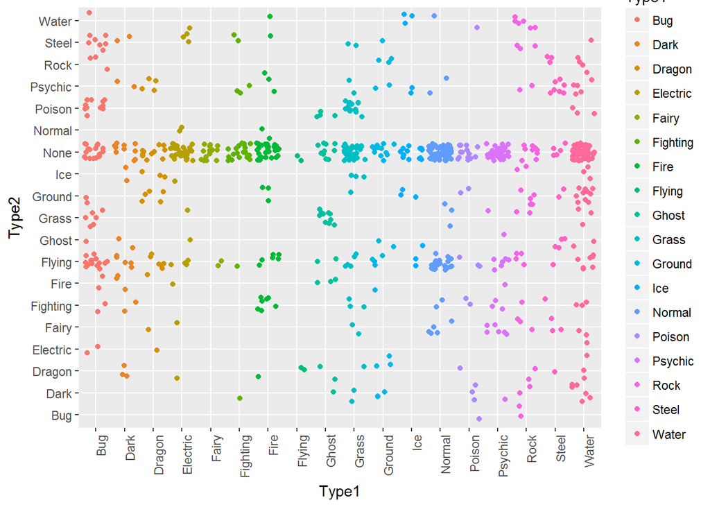

Next was looking at the base stats with types through box plots.

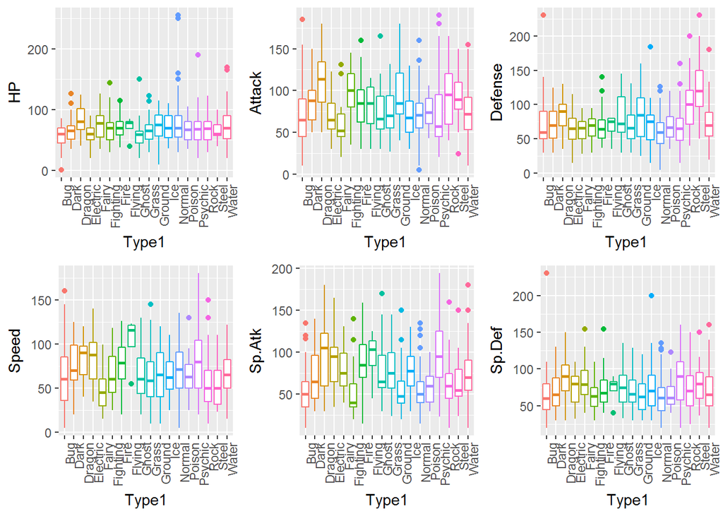

For type 1, it looks like HP, Defense, and Special Defense are fairly close across types. Outstanding for defense, Rock and Steel seem to be higher which makes intuitive sense. The highly varied distributions of Attack, Special Attack, and Speed will likely have a large influence on the model.

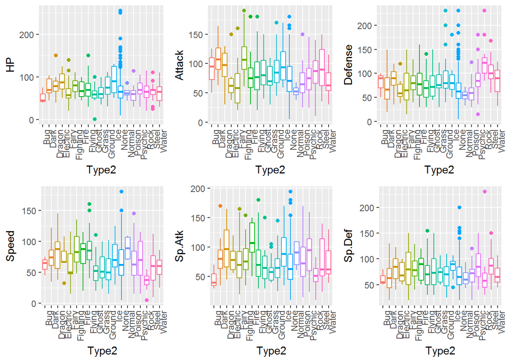

For Type 2, the distributions of the box plots seem to follow the overall pattern of the Type 1 plots. It is notable that since a majority of pokemon had only one type, they were all thrown into a single category for these plots under “None”. Keeping this in mind, the interesting part is that since the boxes are fairly consistent then the types may be correlated with the pokemon’s base statistics. Since there are few variables, they were all incorporated into the model:

```
##  [1] "Type1"      "Type2"      "HP"         "Attack"     "Defense"
##  [6] "Sp.Atk"     "Sp.Def"     "Speed"      "Generation" "Legendary"
```

When it came to feature engineering, the only variable missing that came to mind was the type advantage any given pokemon would have over another. This required the creation of a simple 18x18 table of what effect one pokemon would have over the other: No effect of 0, Not Very Effective of 0.5, Normal of 1, or Super Effective of 2. Since a pokemon can have at most two types, a matchup can result in type advantages of 0, 0.25, 0.5, 1, 2, and 4, so two type advantage variables were created for each possibility. An interaction term of the two type advantage variables for the model was considered; however, the possibility of an interaction of 0 and 4 and other such combinations would have been problematic so it was left out. Because the data frame had grown relatively large with including both pokemons’ relevant stats, the difference in their statistics was used in order to cut down on the variables used in the model which would maintain any advantage a pokemon had over another in a given statistic.

The features were ready to be incorporated into the model. The combat dataset which contained 50,000 simulated battles was split into a training and test set with a 80/20 split. Logistic regression was the first model used for classification. As a preliminary step, model selection procedures were used by trying forward, backward, and stepwise selection. All three procedures returned the same model with all parameters with an AIC of 28680. So I proceeded to run the full model.

```
##    y_pred
##        0    1
##   0 4687  593
##   1  594 4126
```

```
## [1] 0.8813
```

[output not shown]

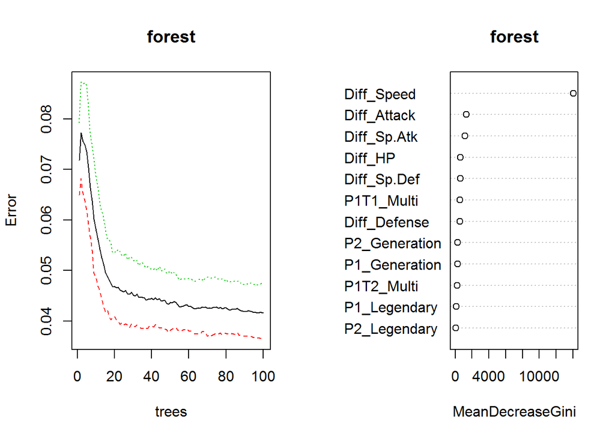

```
##    prob_pred_rf
##        0    1
##   0 5067  213
##   1  233 4487
```

```
## [1] 0.9554
```

The random forest model was applied to the remaining test data set did not include outcomes of battles. The battles were aggregated into win percentages for individual pokemon and by type. From the results, the best pokemon were selected to be Weaville, Aerodactyl, Mismagius, Sceptile, Talonflame, and Charizard. The best types were Flying and Fire but it looks like in type 2 it was close between three other types.

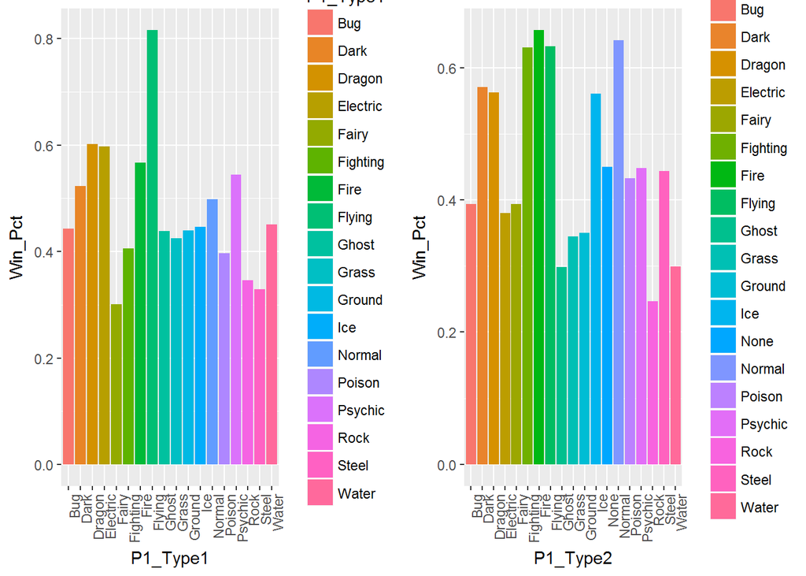